# Weight Lifting Wearables Project

The goal of this project is to predict “how” subjects are performing a weight lifting exercise, i.e. the “classe” variable A, B, C, D, E. These represent different ways of performing the exercise, correctly or with certain common mistakes.

# Prerequisites

#### Install packages

```r
library(tidyverse)
library(caret)
library(dplyr)
```

#### Download data

```r
data_folder = '/domino/datasets/local/R-learning-sandbox/'
training_url = 'https://d396qusza40orc.cloudfront.net/predmachlearn/pml-training.csv'
testing_url = 'https://d396qusza40orc.cloudfront.net/predmachlearn/pml-testing.csv'
training_file = file.path(data_folder, "pml-training.csv")
testing_file = file.path(data_folder, "pml-testing.csv")
download.file(training_url, training_file)
download.file(testing_url, testing_file)
```

# Explore the data

#### Read Data

```r
training_data = read.csv(training_file, na.strings=c("", "NA"), row.names = "X")
testing_data = read.csv(testing_file, na.strings=c("", "NA"), row.names = "X")
```

#### Look at column NAs

```r
no_na_col_lists = c()
for (d in c("training", "testing")) {
  if (d == "training") current_data = training_data
  else current_data = testing_data
  data_dim = dim(current_data)
  print(sprintf("For %s data (%d rows, %d columns):", d, data_dim[[1]], data_dim[[2]]))
  na_cols = summarise_all(current_data, ~ mean(is.na(.)))
  na_stats = table(t(na_cols)[,1])
  for (i in 1:length(na_stats)) {
    print(sprintf(
      "...there are %s columns where %s%% are NA",
      toString(na_stats[i]),
      as.numeric(names(na_stats[i]))*100
      ))
  }
  if (d == "training") {
    no_na_cols_training = names(na_cols)[which(t(na_cols) == 0)]
  }
  else {
    no_na_cols_testing = names(na_cols)[which(t(na_cols) == 0)]
    print("Good (0 na columns) in training data that are not good in testing data:")
    print(setdiff(no_na_cols_training, no_na_cols_testing))
    print("Good (0 na columns) in testing data that are not good in training data:")
    print(setdiff(no_na_cols_testing, no_na_cols_training))
  }
}
```

```
## [1] "For training data (19622 rows, 159 columns):"
## [1] "...there are 59 columns where 0% are NA"
## [1] "...there are 100 columns where 97.9308938946081% are NA"
## [1] "For testing data (20 rows, 159 columns):"
## [1] "...there are 59 columns where 0% are NA"
## [1] "...there are 100 columns where 100% are NA"
## [1] "Good (0 na columns) in training data that are not good in testing data:"
## [1] "classe"
## [1] "Good (0 na columns) in testing data that are not good in training data:"
## [1] "problem_id"
```

There is a clear pattern here, with a bunch of columns that are almost entirely NA in the training data. These same columns are 100% NA in the testing data. Probably we can ignore those columns, but is there something special about the few non-NA entries in those columns?

#### Look at row NAs

```r
complete_rows = complete.cases(training_data)
print(sprintf(
  "Training data has %f%% of rows with some NAs",
  100*(1 - sum(complete_rows)/nrow(training_data))
))
```

```
## [1] "Training data has 97.930894% of rows with some NAs"
```

The percentage of rows with some NAs is identical to what we saw for columns. So, the NAs are all “grouped together”, i.e. a row has either all NA or zero NA in those columns. I am going to treat those rows with no NAs as invalid and get rid of them, since they do not match the structure of the testing data we have to predict on.

(They appear to be rows that include window aggregations of some kind. They are probably all the rows with “new_window” = “yes”, but it’s not worth checking.)

# Clean up the data

#### Drop NA columns

Have a look at the training data after as a sanity check.

```r
training_data_clean = training_data %>%
  filter(!complete_rows) %>%
  select(all_of(no_na_cols_training))
testing_data_clean = testing_data %>%
  select(all_of(no_na_cols_testing))
glimpse(training_data_clean)
```

```
## Rows: 19,216
## Columns: 59
## $ user_name            <chr> "carlitos", "carlitos", "carlitos", "carlitos", "…
## $ raw_timestamp_part_1 <int> 1323084231, 1323084231, 1323084231, 1323084232, 1…
## $ raw_timestamp_part_2 <int> 788290, 808298, 820366, 120339, 196328, 304277, 3…
## $ cvtd_timestamp       <chr> "05/12/2011 11:23", "05/12/2011 11:23", "05/12/20…
## $ new_window           <chr> "no", "no", "no", "no", "no", "no", "no", "no", "…
## $ num_window           <int> 11, 11, 11, 12, 12, 12, 12, 12, 12, 12, 12, 12, 1…
## $ roll_belt            <dbl> 1.41, 1.41, 1.42, 1.48, 1.48, 1.45, 1.42, 1.42, 1…
## $ pitch_belt           <dbl> 8.07, 8.07, 8.07, 8.05, 8.07, 8.06, 8.09, 8.13, 8…
## $ yaw_belt             <dbl> -94.4, -94.4, -94.4, -94.4, -94.4, -94.4, -94.4, …
## $ total_accel_belt     <int> 3, 3, 3, 3, 3, 3, 3, 3, 3, 3, 3, 3, 3, 3, 3, 3, 3…
## $ gyros_belt_x         <dbl> 0.00, 0.02, 0.00, 0.02, 0.02, 0.02, 0.02, 0.02, 0…
## $ gyros_belt_y         <dbl> 0.00, 0.00, 0.00, 0.00, 0.02, 0.00, 0.00, 0.00, 0…
## $ gyros_belt_z         <dbl> -0.02, -0.02, -0.02, -0.03, -0.02, -0.02, -0.02, …
```

[output cut: 46 more lines]

#### Drop non-feature columns

We can see some non-feature columns in the above data, so remove them.

```r
more_cols_to_remove = c(
  "user_name",
  "raw_timestamp_part_1",
  "raw_timestamp_part_2",
  "cvtd_timestamp",
  "new_window",
  "num_window"
  )
training_data_cleanest = select(training_data_clean, -all_of(more_cols_to_remove))
```

#### Format target variable as factor

```r
training_data_cleanest$classe = as.factor(training_data_cleanest$classe)
```

#### Split training and validation data

Since the final data I have to predict on is called “testing data”, I will call my holdout data for training “validation data”.

```r
set.seed(42)
inTrainSet = createDataPartition(training_data_cleanest$classe, p=0.8, list=FALSE)
train_set = training_data_cleanest[inTrainSet,]
val_set = training_data_cleanest[-inTrainSet,]
```

#### Look at target variable

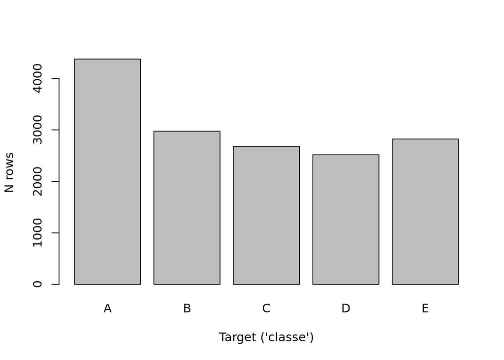

```r
barplot(table(train_set$classe), xlab="Target ('classe')", ylab="N rows")
```

# Train and evaluate models

#### Random guess baseline

Start with a very basic model that makes a random guess. It is weighted by how often each class comes up, but that’s all. Notice the baseline accuracy, just a little better than 1/5 for 5 classes.

```r
random_guess_predictions = function(df_to_predict) {
  random_guess_model_weights = table(train_set$classe)
  set.seed(42)
  preds = slice_sample(
    data.frame(names(random_guess_model_weights)),
    n = nrow(df_to_predict),
    weight_by = as.numeric(random_guess_model_weights),
    replace = TRUE
  )
  names(preds) = c("classe")
  preds$classe = as.factor(preds$classe)
  return(preds)
}
cm = confusionMatrix(
  random_guess_predictions(train_set)$classe,
  train_set$classe
)
print(cm$table)
```

```
##           Reference
## Prediction    A    B    C    D    E
##          A 1265  834  794  708  824
##          B  815  569  512  473  530
##          C  798  505  475  429  485
##          D  734  484  415  440  437
##          E  765  583  486  468  547
```

```r
print(cm$overall["Accuracy"])
```

```
## Accuracy
## 0.214374
```

#### Random forest on subset of rows

Random Forests are a good general purpose algorithm with few assumptions about the data, so no need to do a bunch more cleanup/preprocessing (scaling etc). Training time on the full data with all defaults (including tuning, etc) was slow, so I want to try some things on a reduced set first and see if I can speed it up.

Using out-of-bag instead of other cross-validation methods here because it is fast, and just for fun based on the options in the documentation. I tried other methods as well (e.g. “cv” instead of “oob”), but not including that code here to keep knitting time reasonable. https://topepo.github.io/caret/model-training-and-tuning.html#the-traincontrol-function

```r
reduced_train_set = slice_sample(train_set, n=1000)
t1 = Sys.time()
first_model = train(
  classe ~ .,
  data=reduced_train_set,
  method='rf',
  tuneGrid=expand.grid(mtry=c(5,10,20)),
  trControl = trainControl(method = "oob")
  )
print(Sys.time() - t1)
```

```
## Time difference of 8.158999 secs
```

Look at the results, notice there is not much difference. I will stick to mtry=5 for future training to save time.

```r
first_model
```

```
## Random Forest
##
## 1000 samples
##   52 predictor
##    5 classes: 'A', 'B', 'C', 'D', 'E'
##
## No pre-processing
## Resampling results across tuning parameters:
##
##   mtry  Accuracy  Kappa
##    5    0.902     0.8762356
##   10    0.909     0.8850671
##   20    0.905     0.8799758
##
## Accuracy was used to select the optimal model using the largest value.
## The final value used for the model was mtry = 10.
```

#### Random forest on subset of rows and subset of columns

Can I pick out the most important features to further reduce training time? That would be nice when I get to the full sample, in case I want to return to hyperparameter tuning, or quickly try other models on a reduced list of features (without sacrificing too much in accuracy). This is also an excuse to play with k-fold cross-validation a bit manually.

```r
use_cols = row.names(varImp(first_model$finalModel))
n_feature_grid = c(5, 10, 20, 40, 50)
accuracy_grid = c()
set.seed(42)
folds = createFolds(reduced_train_set$classe, k=3, list=TRUE, returnTrain=TRUE)
folds_accuracy = c()
for (i in 1:length(n_feature_grid)) {
  n_features = n_feature_grid[[i]]
  print(sprintf("Trying with %d features", n_features))
  t1 = Sys.time()
  current_accuracy = c()
  for (j in 1:length(folds)) {
    current_data = reduced_train_set %>%
      select(all_of(c(use_cols[1:n_features], "classe")))
    current_model = train(
      classe ~ .,
      data=current_data[folds[[j]],],
      method='rf',
      tuneGrid=data.frame(mtry=5),
      trControl = trainControl(method = "none"))
    cm = confusionMatrix(
      predict(current_model, current_data[-folds[[j]],]),
      current_data[-folds[[j]],]$classe
    )
    current_accuracy = c(current_accuracy, as.numeric(cm$overall["Accuracy"]))
  }
  print(Sys.time() - t1)
  accuracy_grid = c(accuracy_grid, mean(current_accuracy))
  folds_accuracy = c(folds_accuracy, current_accuracy)
}
```

```
## [1] "Trying with 5 features"
## Time difference of 1.750501 secs
## [1] "Trying with 10 features"
## Time difference of 2.00595 secs
## [1] "Trying with 20 features"
## Time difference of 2.557396 secs
## [1] "Trying with 40 features"
## Time difference of 3.466609 secs
## [1] "Trying with 50 features"
## Time difference of 4.014266 secs
```

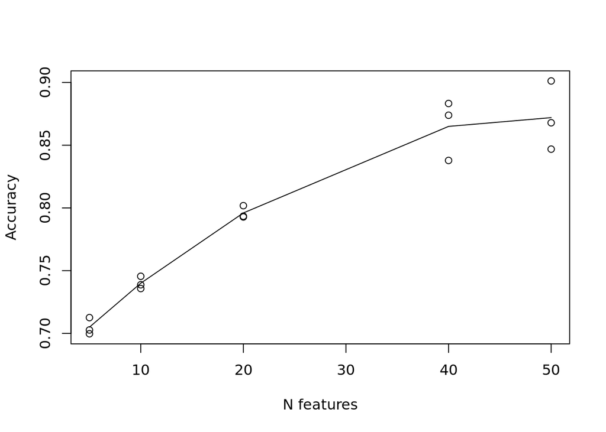

```r
plot(rep(n_feature_grid, each=3), folds_accuracy, xlab="N features", ylab="Accuracy")
lines(n_feature_grid, accuracy_grid)
```

Ok, it seems that the accuracy keeps going up and we need all the features.

#### Random forest on full training set

Now train on the whole training set.

```r
print("Training on the whole train set")
```

```
## [1] "Training on the whole train set"
```

```r
t1 = Sys.time()
full_model = train(
  classe ~ .,
  data=train_set,
  method='rf',
  tuneGrid=data.frame(mtry=5),
  trControl = trainControl(method = "none"))
print(Sys.time() - t1)
```

```
## Time difference of 36.02679 secs
```

#### In vs out of sample error

Let’s actually look at both in and out of sample error here. Notice the overfitting on the training data! Still, out-of-sample error is also very good - this 99% is much better than the 90% or so I was getting on the reduced data set. So, I think I am done here.

```r
cm_train = confusionMatrix(predict(full_model, train_set), train_set$classe)
print(sprintf("Train accuracy: %f", as.numeric(cm_train$overall["Accuracy"])))
```

```
## [1] "Train accuracy: 1.000000"
```

```r
cm_val = confusionMatrix(predict(full_model, val_set), val_set$classe)
print(sprintf("Validation accuracy: %f", as.numeric(cm_val$overall["Accuracy"])))
```

```
## [1] "Validation accuracy: 0.995053"
```

# Get the final test predictions

```r
preds_to_save = select(testing_data_clean, "problem_id")
preds_to_save$pred = predict(full_model, testing_data_clean)
write.csv(preds_to_save, "/mnt/PracticalMachineLearning/Week4project_preds.csv", row.names = FALSE)
preds_to_save
```

```
##    problem_id pred
## 1           1    B
## 2           2    A
## 3           3    B
## 4           4    A
## 5           5    A
## 6           6    E
## 7           7    D
## 8           8    B
## 9           9    A
## 10         10    A
## 11         11    B
## 12         12    C
## 13         13    B
## 14         14    A
## 15         15    E
## 16         16    E
## 17         17    A
## 18         18    B
## 19         19    B
## 20         20    B
```